# Introduction

**Residual Sugar:**

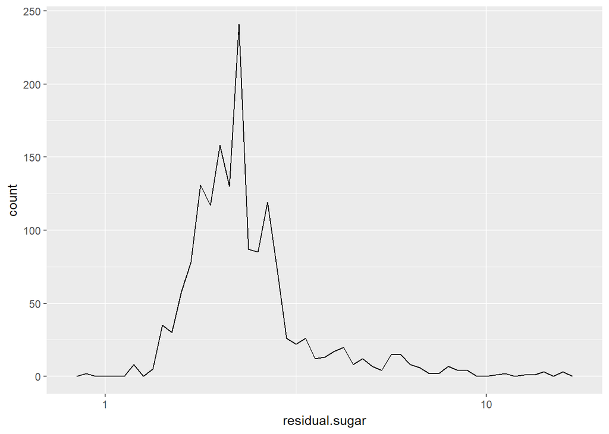

```
##    Min. 1st Qu.  Median    Mean 3rd Qu.    Max.
##   0.900   1.900   2.200   2.539   2.600  15.500
```

Resdidual suagr is the amount of sugar left after fermentation. Wines with more than 45/g of residual sugar are considered sweet. I applied log10 to get a better and more normalized spread of the data. It has a mean of 2.5 but the median, 2.2 is more representative of the data given the outliers.

**pH:**

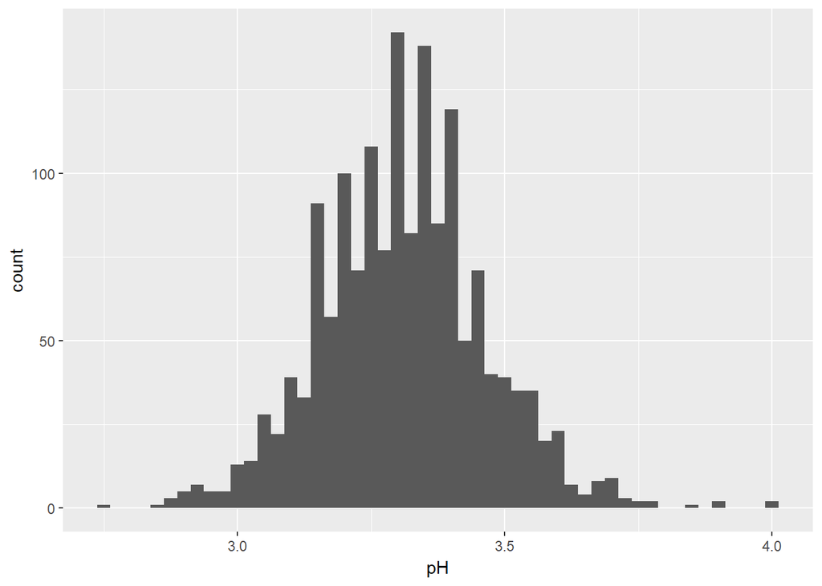

```
##    Min. 1st Qu.  Median    Mean 3rd Qu.    Max.
##   2.740   3.210   3.310   3.311   3.400   4.010
```

pH is the measurement of how basic or acidic a substance is on a scale of 0-14, 0 being the most acidic and 14 the most basic. MOst wines have a pH between 3 and 4. This data set has a normal distribution of pH withe the majority being between 3 and 4, as expected. The overall mean is 3.3.

**Chloride:**

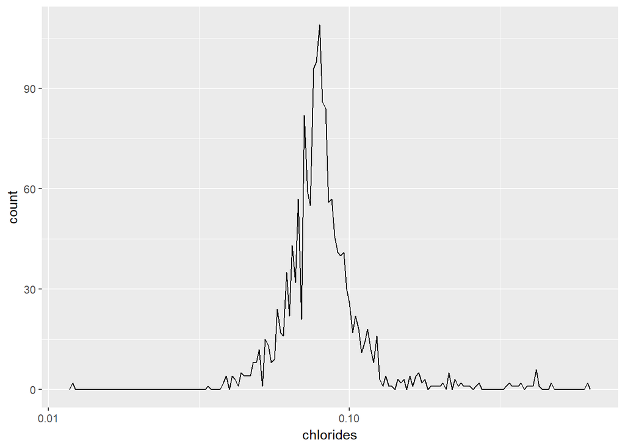

```
##    Min. 1st Qu.  Median    Mean 3rd Qu.    Max.
## 0.01200 0.07000 0.07900 0.08747 0.09000 0.61100
```

Chlorides are the amount of salt in wine. I applied log10 to normalize the distribution. The mean chloride level is 0.09.